# Reduce mental burden in plots

# 3 Were there more men or women on the Titanic?

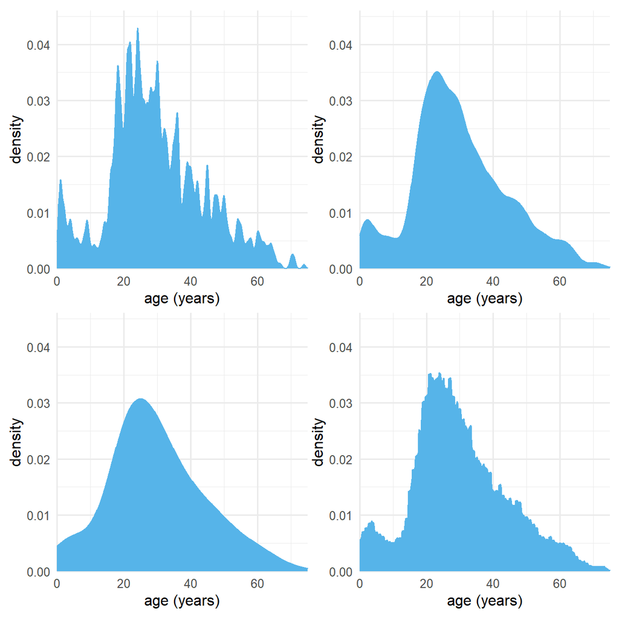

```r
# adapted from https://clauswilke.com/dataviz/histograms-density-plots.html#multiple-histograms-densities

# get titanic data
url <- "http://biostat.mc.vanderbilt.edu/wiki/pub/Main/DataSets/titanic3.csv"
titanic <- vroom(url)

# First, explore effect of different values of bandwith in geom_density()
# bw    :The smoothing bandwidth to be used, siilar to a histogram's binwidth

pdens1 <- ggplot(titanic, aes(x = age)) +
  geom_density(fill = "#56B4E9", color = "#56B4E9", bw = .5, kernel = "gaussian") +
  scale_y_continuous(limits = c(0, 0.046), expand = c(0, 0), name = "density") +
  scale_x_continuous(name = "age (years)", limits = c(0, 75), expand = c(0, 0)) +
  coord_cartesian(clip = "off") +
  theme_minimal(12) +
  theme(
    axis.line.x = element_blank(),
    plot.margin = margin(3, 1.5, 3, 1.5)
  )

pdens2 <- ggplot(titanic, aes(x = age)) +
 geom_density(fill = "#56B4E9", color = "#56B4E9", bw = 2, kernel = "gaussian") +
  scale_y_continuous(limits = c(0, 0.046), expand = c(0, 0), name = "density") +
  scale_x_continuous(name = "age (years)", limits = c(0, 75), expand = c(0, 0)) +
  coord_cartesian(clip = "off") +
  theme_minimal(12)  +
  theme(
    axis.line.x = element_blank(),
    plot.margin = margin(3, 1.5, 3, 1.5)
  )

pdens3 <- ggplot(titanic, aes(x = age)) +
 geom_density(fill = "#56B4E9", color = "#56B4E9", bw = 5, kernel = "gaussian") +
  scale_y_continuous(limits = c(0, 0.046), expand = c(0, 0), name = "density") +
  scale_x_continuous(name = "age (years)", limits = c(0, 75), expand = c(0, 0)) +
  coord_cartesian(clip = "off") +
  theme_minimal(12)  +
  theme(
    axis.line.x = element_blank(),
    plot.margin = margin(3, 1.5, 3, 1.5)
  )

pdens4 <- ggplot(titanic, aes(x = age)) +
  geom_density(fill = "#56B4E9", color = "#56B4E9", bw = 2, kernel = "rectangular") +
  scale_y_continuous(limits = c(0, 0.046), expand = c(0, 0), name = "density") +
  scale_x_continuous(name = "age (years)", limits = c(0, 75), expand = c(0, 0)) +
  coord_cartesian(clip = "off") +
  theme_minimal(12)  +
  theme(
    axis.line.x = element_blank(),
    plot.margin = margin(3, 1.5, 3, 1.5)
  )

# use patchwork to arrange plots
(pdens1 + pdens2) / (pdens3 + pdens4)
```

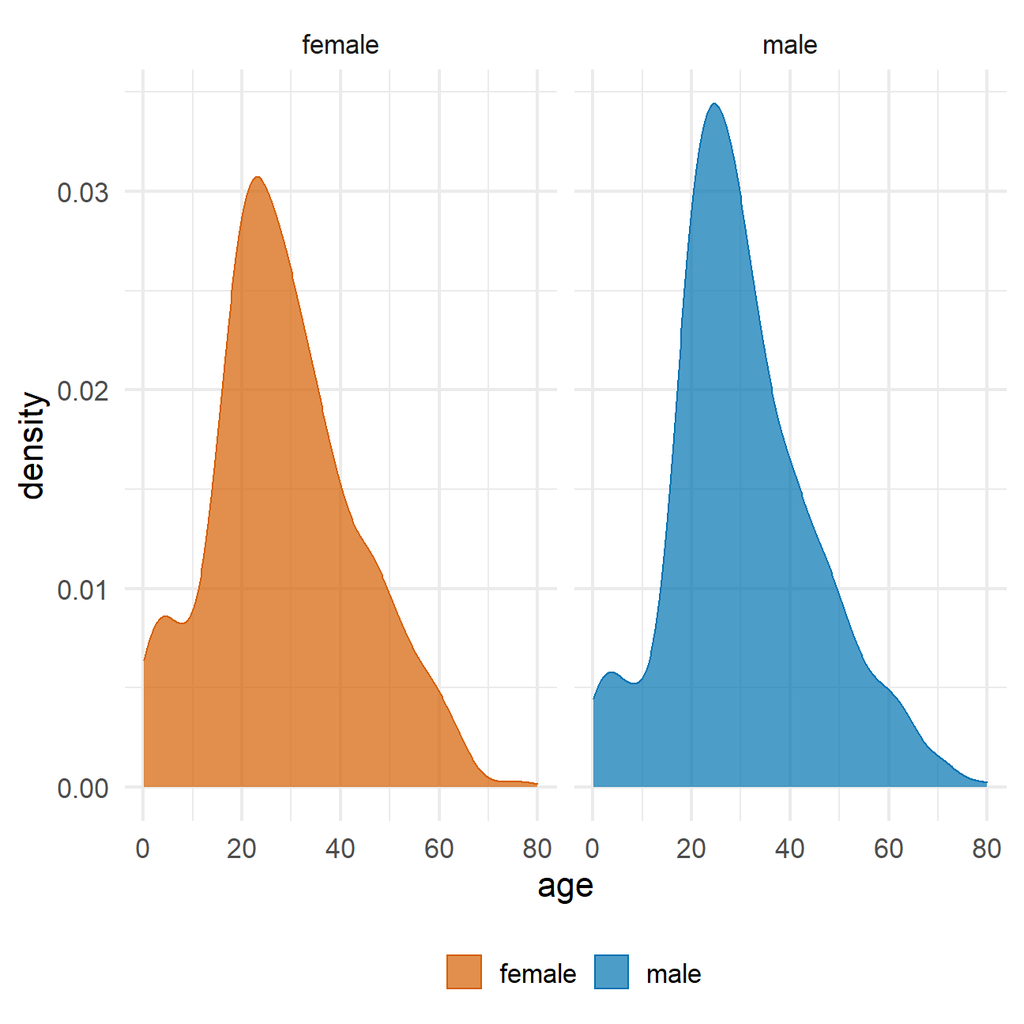

```r
# Define a vector of colours... grey80 for background, and two different colours for male/female
density_colours <- c(
  "male" = "#0072B2",
  "female" = "#D55E00",
  "all passengers" = "grey80"
)

# the default density plot + facet_wrap-- difference between men and women seems small
titanic %>%
  drop_na(sex, age) %>% # remove NAs for sex and age
  ggplot(aes(age)) +
  geom_density(aes(fill = sex, colour = sex), alpha = 0.7) +
  scale_color_manual(name = NULL, values = density_colours) +
  scale_fill_manual(name = NULL, values = density_colours) +
  theme_minimal(16) +
  theme(legend.position = "bottom", legend.justification = "center")+
  facet_wrap(~sex)+
  NULL
```

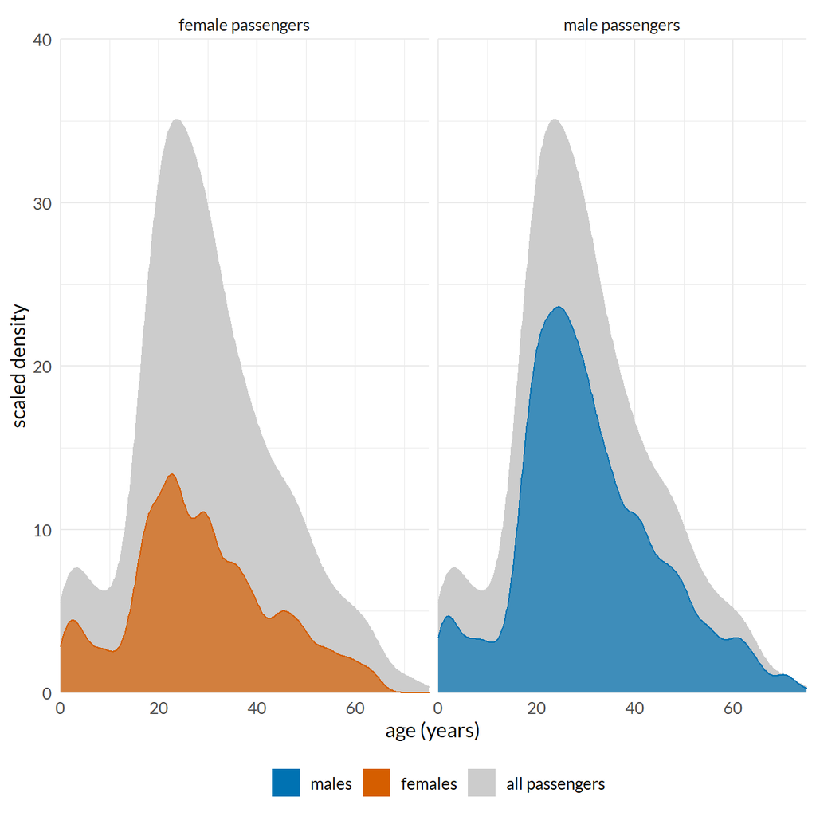

```r
titanic %>%
  drop_na(sex, age) %>% # remove NAs for sex and age, and pass dataframe to ggplot

  # in the ggplot(), besides `x = age`, add `y = ..count..` to `aes()`
  ggplot(aes(x = age, y = ..count..)) +


  # Add an additional `geom_density()` that will draw the background density, for all participants.
  # This should come *before* the 'normal' `geom_density()` so that it draws the background.
  geom_density(

    # In the background geom_density(), set the `data` argument to be a function. This function
    # takes a data frame and removes sex (select x, -sex) (on which sex we will facet on later).
    data = function(x) select(x, -sex),

    # Set both `colour` and `fill` equal to "all passengers", *not* `sex`.
    aes(fill = "all passengers", colour = "all passengers")
  ) +

  # now that we have the grey background, we can plot densities
  # coloured and facet_wrapped by sex
  geom_density(aes(fill = sex, colour = sex), alpha = 0.7, bw = 2) +

  # `facet_wrap()` to facet the plot by `sex`.
  # labeller() makes it easy to assign different labellers to different factors
  facet_wrap(~sex, labeller = labeller(sex = function(sex) paste(sex, "passengers"))) +


  # use the colours you defined for male, female, and all participants
  scale_colour_manual(
    values = density_colours,
    breaks = c("male", "female", "all passengers"),
    labels = c( "males", "females","all passengers"),
    name = NULL,
    guide = guide_legend(direction = "horizontal")
  )+
  scale_fill_manual(
    values = density_colours,
    breaks = c("male", "female", "all passengers"),
    labels = c( "males", "females","all passengers"),
    name = NULL,
    guide = guide_legend(direction = "horizontal")
  )+
  scale_x_continuous(name = "age (years)", limits = c(0, 75), expand = c(0, 0)) +
  scale_y_continuous(limits = c(0, 40), expand = c(0, 0), name = "scaled density") +
  coord_cartesian(clip = "off") +
  theme_minimal() +
  theme(legend.position = "bottom",
        legend.justification = "center",
        text=element_text(size=12, family="Lato"),
        plot.title.position = "plot"
  ) +
  NULL
```

# 4 `gghighlight`

We want to create a graph that looks at African countriews were life expectancy between 1992 and 2007 went down.

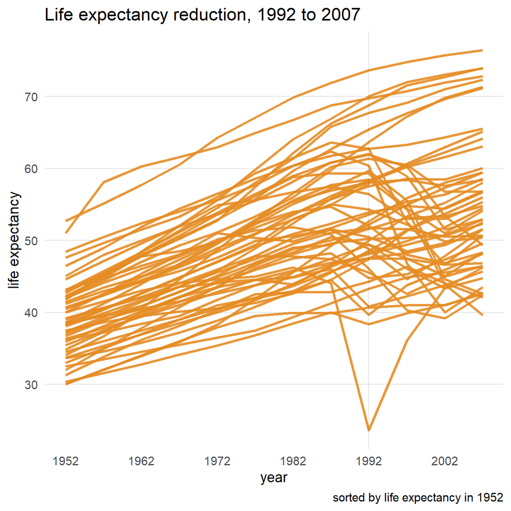

```r
africa <- gapminder %>%
  filter(continent == "Africa") %>%
  # sort by life expectancy in 1952, the first year in the dataframe
  arrange(year, desc(lifeExp)) %>%
  mutate(country = fct_inorder(factor(country)))

# find the African countries that had better life expectancy in 1992 compared to 2007
life_expectancy_dropped <- africa %>%

  # pivot wider to be able to compare life expectancy in 1992 to 2007,
  pivot_wider(country, names_from = year, values_from = lifeExp) %>%

  # create new variables, `le_dropped`, that is `TRUE` if life expectancy was higher in 1992
  # and `le_delta` which is simply the difference between life expectancy in 2007 and 1992
  mutate(
    le_delta = `2007` - `1992`,
    le_dropped = `1992` > `2007`) %>%
  select(-c(2:13))

# join `le_dropped` to each observation for each country
africa <- left_join(africa, life_expectancy_dropped, by = "country")

le_line_plot <- africa %>%
  ggplot(aes(year, lifeExp, color = country, group = country)) +
  geom_line(size = 1.2, alpha = 0.9, color = "#E58C23") +
  theme_minimal(base_size = 14) +

  # let us add a vertical line at 1992, when we start our comparison
  geom_vline(xintercept = 1992, alpha = 0.1)+

  theme(
    # remove legend using the legend.position argument in theme()
    # ________________,
    panel.grid.major.x = element_blank(),
    panel.grid.minor = element_blank()
  ) +
  labs(
    title = "Life expectancy reduction, 1992 to 2007",
    y = "life expectancy",
    caption = "sorted by life expectancy in 1952") +
  scale_x_continuous(breaks = seq(1952, 2007, 10))+
  NULL

le_line_plot
```

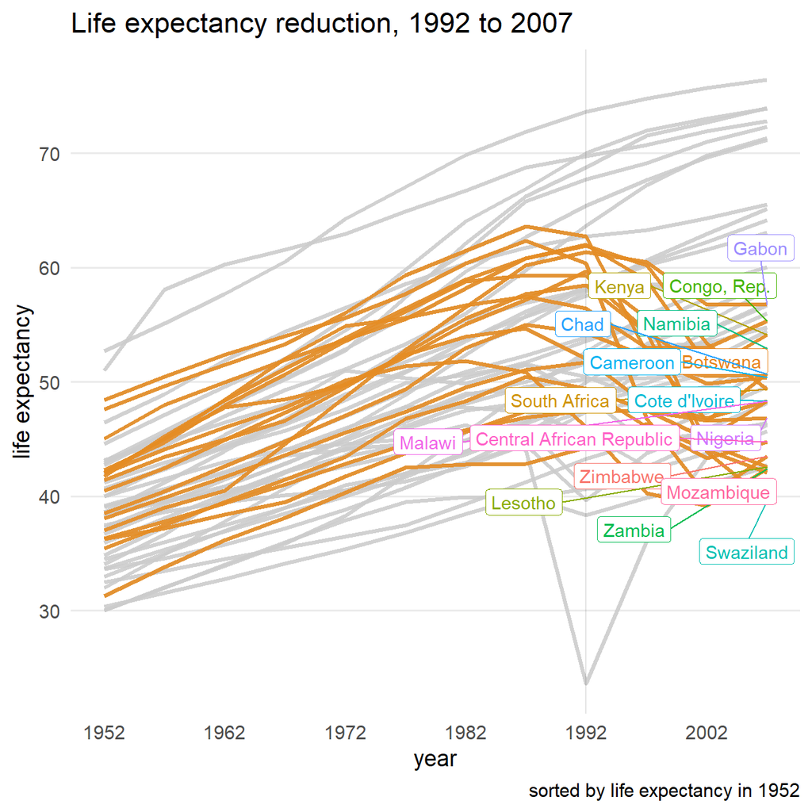

```r
# Using `gghighlight()` we add add direct labels to the plot.
# The first argument defines which lines to highlight using `le_dropped`.
# Also add the arguments `use_group_by = FALSE` and `unhighlighted_colour = "grey80"`.

le_line_plot +
  gghighlight(
    le_dropped,
    use_group_by = FALSE,
    unhighlighted_colour = "grey80"
  )
```

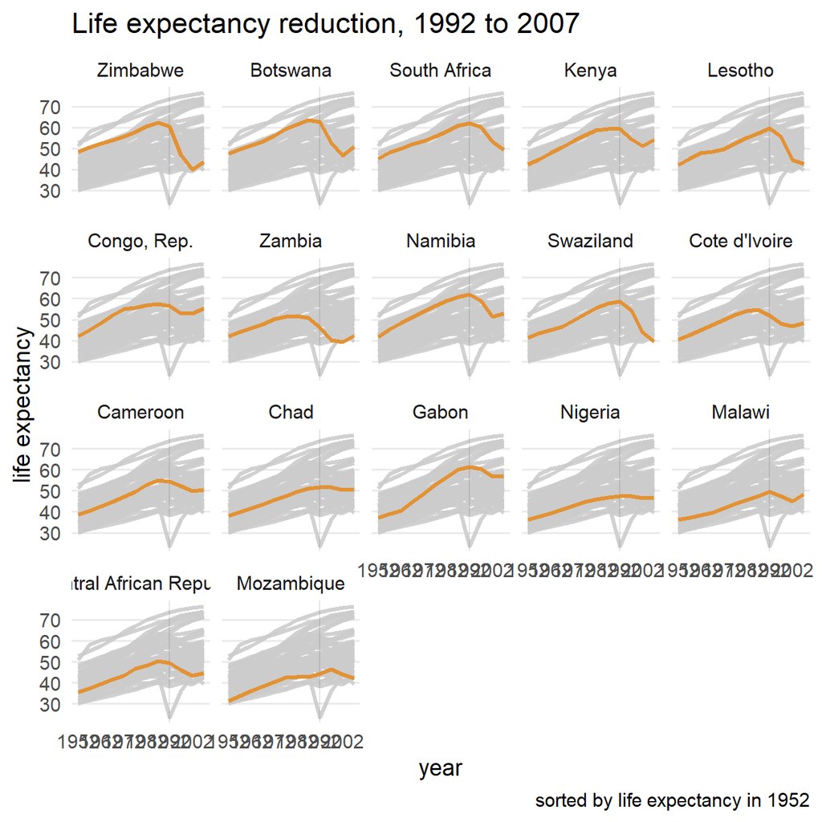

```r
#  If we facet_wrap() we do not need direct labels, so set `use_direct_label = FALSE`

le_line_plot +
  gghighlight(
    le_dropped,
    use_group_by = FALSE,
    use_direct_label = FALSE,
    unhighlighted_colour = "grey80"
  ) +
  facet_wrap(~country)
```

# 5 On your own: NYC Dogs

This is to get you started on your own. You can install the relevant `nycdogs` package and read more about it here https://kjhealy.github.io/nycdogs/

```r
# load the data
data("nyc_license")
data("nyc_zips")

# what is the prevalent NYC breed ?
nyc_license %>%
  count(breed_rc, sort=TRUE)
```

```
## # A tibble: 301 x 2
##    breed_rc                     n
##    <chr>                    <int>
##  1 Unknown                  16797
##  2 Yorkshire Terrier         7786
##  3 Shih Tzu                  7154
##  4 Labrador (or Crossbreed)  6986
##  5 Pit Bull (or Mix)         6751
##  6 Chihuahua                 5785
##  7 Maltese                   4308
##  8 Pomeranian                2197
##  9 Beagle                    2111
## 10 Jack Russell Terrier      2041
## # ... with 291 more rows
```

```r
# what is the prevalent NYC dog name by animal gender?
# Bella for girls, Max for boys!

nyc_license %>%
  count(animal_name, animal_gender, sort=TRUE)
```

```
## # A tibble: 19,294 x 3
##    animal_name       animal_gender     n
##    <chr>             <chr>         <int>
##  1 Unknown           M              1401
##  2 Bella             F              1365
##  3 Max               M              1272
##  4 Name Not Provided M              1111
##  5 Unknown           F              1093
##  6 Lola              F               875
##  7 Charlie           M               871
##  8 Rocky             M               869
##  9 Lucy              F               767
## 10 Buddy             M               743
## # ... with 19,284 more rows
```

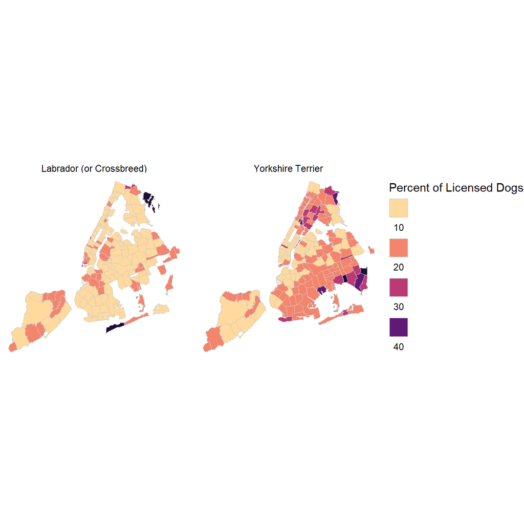

```r
# Maps for two Breeds
top_breeds <- nyc_license %>%
  group_by(zip_code, breed_rc) %>%
  tally() %>%
  filter(n>10) %>%
  mutate(freq = n / sum(n),
         pct = round(freq*100, 2)) %>%
  filter(breed_rc == "Yorkshire Terrier" |  breed_rc == "Labrador (or Crossbreed)")



top_breeds_map <- left_join(nyc_zips, top_breeds) %>%
  na.omit()


top_breeds_map %>% ggplot(mapping = aes(fill = pct)) +
  geom_sf(color = "gray80", size = 0.1) +
  scale_fill_viridis_b(option = "A", direction= -1) +
  labs(fill = "Percent of Licensed Dogs") +
  facet_wrap(~breed_rc)+
  theme_void() +
  guides(fill = guide_legend(title.position = "top",
                             label.position = "bottom"))
```

# 6 On your own: Coffee ratings

Coffee ratings. Which country produces the best coffee? Does location and altitude of cultivation play a role?

You can see someone’s analysis here https://towardsdatascience.com/the-data-speak-ethiopia-has-the-best-coffee-91f88ed37e84

```r
url <- 'https://raw.githubusercontent.com/rfordatascience/tidytuesday/master/data/2020/2020-07-07/coffee_ratings.csv'

coffee_ratings <- vroom(url)

skim(coffee_ratings)
```

Data summary

| Name | coffee_ratings |
| --- | --- |
| Number of rows | 1339 |
| Number of columns | 43 |
| _______________________ |  |
| Column type frequency: |  |
| character | 24 |
| numeric | 19 |
| ________________________ |  |
| Group variables | None |

**Variable type: character**

| skim_variable | n_missing | complete_rate | min | max | empty | n_unique | whitespace |
| --- | --- | --- | --- | --- | --- | --- | --- |
| species | 0 | 1.00 | 7 | 7 | 0 | 2 | 0 |
| owner | 7 | 0.99 | 3 | 50 | 0 | 315 | 0 |
| country_of_origin | 1 | 1.00 | 4 | 28 | 0 | 36 | 0 |
| farm_name | 359 | 0.73 | 1 | 73 | 0 | 571 | 0 |
| lot_number | 1063 | 0.21 | 1 | 71 | 0 | 227 | 0 |
| mill | 315 | 0.76 | 1 | 77 | 0 | 460 | 0 |
| ico_number | 151 | 0.89 | 1 | 40 | 0 | 847 | 0 |
| company | 209 | 0.84 | 3 | 73 | 0 | 281 | 0 |
| altitude | 226 | 0.83 | 1 | 41 | 0 | 396 | 0 |
| region | 59 | 0.96 | 2 | 76 | 0 | 356 | 0 |
| producer | 231 | 0.83 | 1 | 100 | 0 | 691 | 0 |
| bag_weight | 0 | 1.00 | 1 | 8 | 0 | 56 | 0 |
| in_country_partner | 0 | 1.00 | 7 | 85 | 0 | 27 | 0 |
| harvest_year | 47 | 0.96 | 3 | 24 | 0 | 46 | 0 |
| grading_date | 0 | 1.00 | 13 | 20 | 0 | 567 | 0 |
| owner_1 | 7 | 0.99 | 3 | 50 | 0 | 319 | 0 |
| variety | 226 | 0.83 | 4 | 21 | 0 | 29 | 0 |
| processing_method | 170 | 0.87 | 5 | 25 | 0 | 5 | 0 |
| color | 218 | 0.84 | 4 | 12 | 0 | 4 | 0 |
| expiration | 0 | 1.00 | 13 | 20 | 0 | 566 | 0 |
| certification_body | 0 | 1.00 | 7 | 85 | 0 | 26 | 0 |
| certification_address | 0 | 1.00 | 40 | 40 | 0 | 32 | 0 |
| certification_contact | 0 | 1.00 | 40 | 40 | 0 | 29 | 0 |
| unit_of_measurement | 0 | 1.00 | 1 | 2 | 0 | 2 | 0 |

**Variable type: numeric**

| skim_variable | n_missing | complete_rate | mean | sd | p0 | p25 | p50 | p75 | p100 | hist |
| --- | --- | --- | --- | --- | --- | --- | --- | --- | --- | --- |
| total_cup_points | 0 | 1.00 | 82.09 | 3.50 | 0 | 81.08 | 82.50 | 83.67 | 9.06e+01 | ▁▁▁▁▇ |
| number_of_bags | 0 | 1.00 | 154.18 | 129.99 | 0 | 14.00 | 175.00 | 275.00 | 1.06e+03 | ▇▇▁▁▁ |
| aroma | 0 | 1.00 | 7.57 | 0.38 | 0 | 7.42 | 7.58 | 7.75 | 8.75e+00 | ▁▁▁▁▇ |
| flavor | 0 | 1.00 | 7.52 | 0.40 | 0 | 7.33 | 7.58 | 7.75 | 8.83e+00 | ▁▁▁▁▇ |
| aftertaste | 0 | 1.00 | 7.40 | 0.40 | 0 | 7.25 | 7.42 | 7.58 | 8.67e+00 | ▁▁▁▁▇ |
| acidity | 0 | 1.00 | 7.54 | 0.38 | 0 | 7.33 | 7.58 | 7.75 | 8.75e+00 | ▁▁▁▁▇ |
| body | 0 | 1.00 | 7.52 | 0.37 | 0 | 7.33 | 7.50 | 7.67 | 8.58e+00 | ▁▁▁▁▇ |
| balance | 0 | 1.00 | 7.52 | 0.41 | 0 | 7.33 | 7.50 | 7.75 | 8.75e+00 | ▁▁▁▁▇ |
| uniformity | 0 | 1.00 | 9.83 | 0.55 | 0 | 10.00 | 10.00 | 10.00 | 1.00e+01 | ▁▁▁▁▇ |
| clean_cup | 0 | 1.00 | 9.84 | 0.76 | 0 | 10.00 | 10.00 | 10.00 | 1.00e+01 | ▁▁▁▁▇ |
| sweetness | 0 | 1.00 | 9.86 | 0.62 | 0 | 10.00 | 10.00 | 10.00 | 1.00e+01 | ▁▁▁▁▇ |
| cupper_points | 0 | 1.00 | 7.50 | 0.47 | 0 | 7.25 | 7.50 | 7.75 | 1.00e+01 | ▁▁▁▇▁ |
| moisture | 0 | 1.00 | 0.09 | 0.05 | 0 | 0.09 | 0.11 | 0.12 | 2.80e-01 | ▃▇▅▁▁ |
| category_one_defects | 0 | 1.00 | 0.48 | 2.55 | 0 | 0.00 | 0.00 | 0.00 | 6.30e+01 | ▇▁▁▁▁ |
| quakers | 1 | 1.00 | 0.17 | 0.83 | 0 | 0.00 | 0.00 | 0.00 | 1.10e+01 | ▇▁▁▁▁ |
| category_two_defects | 0 | 1.00 | 3.56 | 5.31 | 0 | 0.00 | 2.00 | 4.00 | 5.50e+01 | ▇▁▁▁▁ |
| altitude_low_meters | 230 | 0.83 | 1750.71 | 8669.44 | 1 | 1100.00 | 1310.64 | 1600.00 | 1.90e+05 | ▇▁▁▁▁ |
| altitude_high_meters | 230 | 0.83 | 1799.35 | 8668.81 | 1 | 1100.00 | 1350.00 | 1650.00 | 1.90e+05 | ▇▁▁▁▁ |
| altitude_mean_meters | 230 | 0.83 | 1775.03 | 8668.63 | 1 | 1100.00 | 1310.64 | 1600.00 | 1.90e+05 | ▇▁▁▁▁ |